# Robot Routing with a Quantum Processor

James Clark  
STFC Hartree Centre

[figure not shown]

## Motivation

Through collaboartive research, we enable UK industry to adopt the latest digital technologies

# Quantum Annealing

- **Not** equivalent to universal gate based quantum computing
- Takes an initial Hamiltonian and *slowly* evolves it (via adiabatic theorem)
- Encodes a solution the ground state of the final Hamiltonian
- Only "stoquastic hamiltonians" (ground state can be described as classical probability)

[figure not shown]

# Hardware

- D-Wave 2000Q (aims for 2000 qubit yield)
- "Chimera" graph - limited connectivity
- Superconducting loops used as qubits

[figure not shown]

What can we do with this?

- Optimiser, for example: $\min \left(f(\mathbf{x}) = \mathbf{x}^T Q \mathbf{x}\right)$ (QUBO)
- Machine learning
- Materials simulation

## Optimising Example - *"pick one"*

\begin{equation} f(\mathbf{x}) = \left(\sum_{i=0}^{N} x_i - 1\right)^2 \end{equation}

Which gives...

\begin{equation} f(\mathbf{x}) = -x_0 -x_1 \dots -x_N + 2x_0x_1 + \dots + 2x_Nx_{N-1} +1 \end{equation}

Linear terms are the diagonal of $Q$, quadratic are off-diagonal

*D-Wave library requires it's stored in the upper triangle*

```python
Q = {}
for i in range(10):
    for j in range(i+1):
        if (i == j):
            Q[(j,i)] = -1.0
        else:
            Q[(j,i)] = 2.0
```

```python
from dwave.system.samplers import DWaveSampler
from dwave.system.composites import EmbeddingComposite

solver =  EmbeddingComposite(DWaveSampler())
response = solver.sample_qubo(Q, num_reads=500)

samples = list(response.data())
print(samples[0])
```

```
Sample(sample={0: 0, 1: 0, 2: 0, 3: 0, 4: 0, 5: 0, 6: 0, 7: 0, 8: 0, 9: 1}, energy=-1.0, num_occurrences=1)
```

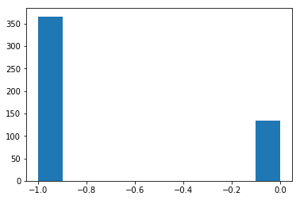

```python
import matplotlib.pyplot as plt
ax = plt.hist(response.data_vectors['energy'])
```

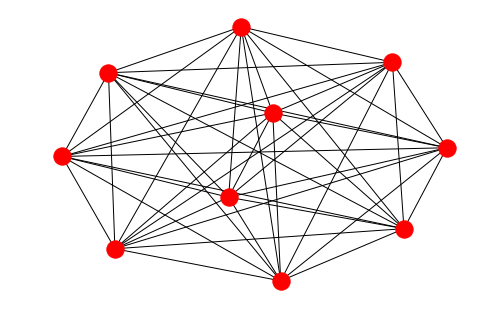

```python
import networkx

networkx.draw(networkx.complete_graph(10))
```

[figure not shown]

# Ocado

Ocado is the world’s largest online-only supermarket

Ocado Technology powers Ocado.com and Morrisons.com

# The Robots

[video not shown]

# Project Rules

- Project is assessing feasibility
- What would an application look like?
- Robots don't accelerate
- All robots are identical
- No faults or performance degradation

# Method

Use annealer to pick optimal combinations of predetermined routes  
Generalisation of VW/D-Wave traffic problem

# Workflow

- Classical route generation (only considering a single robot)
- Quantum optimiser
- Classical validation

[figure not shown]

# Constraints

- One route per robot
  - Same as before: $\left(\sum_{i=0}^{N} x_i - 1\right)^2$
- No collisions
  - $cost(cell,time) = \left(\sum_{q_{ij}\in c_{time}} q_{ij}\right)^2$
- Shortest route is better (implied by previous)
- Minimise turns (add a delay when creating route)
- Other constraints added as needed!

# What about large problems?

## qbsolv

"A decomposing solver that finds a minimum value of a large quadratic unconstrained binary optimization (QUBO) problem by splitting it into pieces."

# First results

[figure not shown]

- OK for first attempt
- There are still collisions
- We can do better!

# Retrying failed attempts

[figure not shown]

- Retry with more routes for failed robots
- Fix robots that were OK
- Collisions are gone
- Cheaper than rerunning whole problem

# Performance

Lower is better

[figure not shown]

# Quantum Processor Usage

Lower is better

[figure not shown]

# Why so slow?

Classical overheads:

- qbsolv's algorithm
- embedding (big one!)
- more work needed here

# Time stepping

Finishing up the touches on time stepping:

- When a robot completes a job, it is given a new one
- Repeat annealing, with new routes and constraints

# Takeaways

- Different to gate based quantum computing
- The D-Wave architecture forced us to think about out problem in a different way.
- Hybrid algorithms are needed (don't throw away your CPUs)
- Embedding the problem on the QPU graph structure is expensive
- Using domain specific knowledge may help with embedding

# Quantum Computing at Hartree

- De-risk proof of concept work with research and industry
- Try all available technologies we have available
  - Gate based machines
  - Quantum annealing devices
  - Simulators on our HPC

# Thanks

- Tristan West (Ocado Technology 10x Team)
- Joseph Zammit (Ocado Technology 10x Team)

# Contact

**Email:** james.clark@stfc.ac.uk  
**Twitter:** [@HartreeCentre](https://twitter.com/HartreeCentre)  
**Web:** hartree.stfc.ac.uk